# Iris Project

Abigail Loy

October 14, 2021

**Machine Learning: *Iris Dataset Classification!***

*Steps:*

1. Bringing the dataset into the R environment.
2. Splitting the data into Training and Testing sets.
3. Exploratory Data Analysis!
4. Fitting the training and testing sets to various models.

*Packages Needed:*

- tidyverse
- caret
- rpart
- rpart.plot
- randomForest
- gbm
- MASS

**-Bringing in the Iris Dataset and Taking a Look!-**

I’ll be loading the dataset from directly within R, though you can also load it from an external source and it’s most likely a good idea for you to do both.

```r
# Packages!
library(tidyverse)
library(caret)
```

```r
library(rpart)
library(rpart.plot)
library(randomForest)
library(gbm)
library(MASS)
#brings data into environment from within R
data(iris)

#help for dataset
help(iris)
```

```
## starting httpd help server ...
```

```
##  done
```

```r
#renames dataset
iris_dataset<-iris

#views dataset
View(iris_dataset)
```

```r
#prints first couple of rows
head(iris)
```

|  | Sepal.Length | Sepal.Width | Petal.Length | Petal.Width | Species |
| --- | --- | --- | --- | --- | --- |
| 1 | 5.1 | 3.5 | 1.4 | 0.2 | setosa |
| 2 | 4.9 | 3.0 | 1.4 | 0.2 | setosa |
| 3 | 4.7 | 3.2 | 1.3 | 0.2 | setosa |
| 4 | 4.6 | 3.1 | 1.5 | 0.2 | setosa |
| 5 | 5.0 | 3.6 | 1.4 | 0.2 | setosa |
| 6 | 5.4 | 3.9 | 1.7 | 0.4 | setosa |

**-Train - Test - Split!-**

Here we’ll be splitting the data into a training and testing set.

The training dataset is to help us understand the data, select the appropriate model and determine model parameters. For this classification problem, we’ll train the model using the classification error rate, which is the percentage of incorrectly/correctly classified instances.

The testing set is for testing our model’s performance when classifying new data. The model performance (error rate) on this new data will be a more realistic estimate of the models performance in the real world.

```r
#creates a partition (80% training, 20% testing)
index <- createDataPartition(iris_dataset$Species, p=0.80, list=FALSE)

#selects 20% of the data for testing
testset <- iris_dataset[-index,]

#selects 80% of data to train models
trainset <- iris_dataset[index,]
```

**-Exploratory Data Analysis-**

Exploring the data is to get us more familiar with the dataset and making sure we understand what the rows and columns are and what the dataset is supposed to be illustrating and how we can use it to build visuals.

```r
#gets dimensions of the dataset
dim(trainset)
```

```
## [1] 120   5
```

```r
#gets structure of the dataset
str(trainset)
```

```
## 'data.frame':    120 obs. of  5 variables:
##  $ Sepal.Length: num  5.1 4.9 4.6 5 5.4 4.6 5 4.4 4.9 5.4 ...
##  $ Sepal.Width : num  3.5 3 3.1 3.6 3.9 3.4 3.4 2.9 3.1 3.7 ...
##  $ Petal.Length: num  1.4 1.4 1.5 1.4 1.7 1.4 1.5 1.4 1.5 1.5 ...
##  $ Petal.Width : num  0.2 0.2 0.2 0.2 0.4 0.3 0.2 0.2 0.1 0.2 ...
##  $ Species     : Factor w/ 3 levels "setosa","versicolor",..: 1 1 1 1 1 1 1 1 1 1 ...
```

```r
#gets summary of the dataset
summary(trainset)
```

```
##   Sepal.Length    Sepal.Width     Petal.Length    Petal.Width
##  Min.   :4.300   Min.   :2.000   Min.   :1.000   Min.   :0.100
##  1st Qu.:5.100   1st Qu.:2.800   1st Qu.:1.600   1st Qu.:0.300
##  Median :5.700   Median :3.000   Median :4.200   Median :1.300
##  Mean   :5.798   Mean   :3.057   Mean   :3.738   Mean   :1.202
##  3rd Qu.:6.300   3rd Qu.:3.300   3rd Qu.:5.100   3rd Qu.:1.800
##  Max.   :7.700   Max.   :4.400   Max.   :6.900   Max.   :2.500
##        Species
##  setosa    :40
##  versicolor:40
##  virginica :40
##
##
##
```

```r
#gets levels of the prediction column
levels(trainset$Species)
```

```
## [1] "setosa"     "versicolor" "virginica"
```

**-Visualizing!-**

Now we need to visualize the data! Visualizing the data helps with understanding it’s various attributes and how they relate to each other. For our plots, we’re going to be making some histograms, box plots, and scatter plots. We’ll start with simplistic plots and then add some flare! Lastly, we’ll try faceting, Which is making multiple charts in one plot.

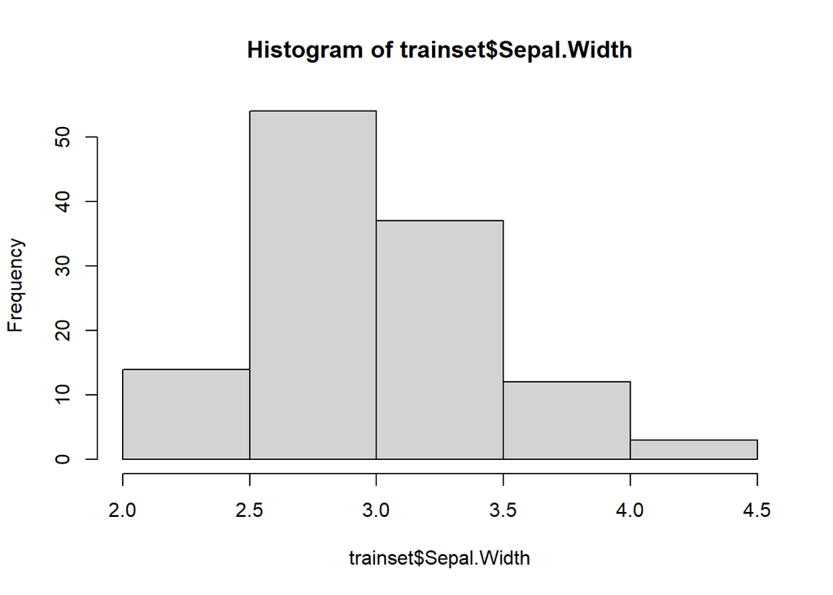

```r
#histogram: frequency of Sepal Width
hist(trainset$Sepal.Width)
```

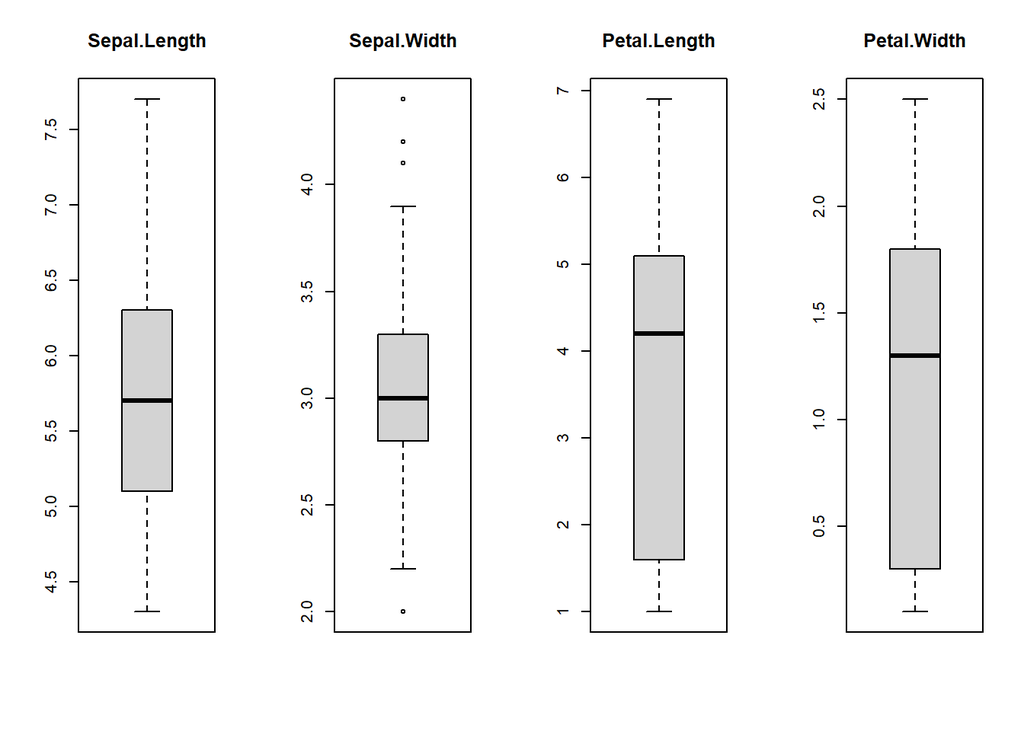

```r
#box plot: how distribution varies by class of flower
par(mfrow=c(1,4))
  for(i in 1:4) {
  boxplot(trainset[,i], main=names(trainset)[i])
}
```

Now we’ll be using the ggplot package to plot some more complicated and precise graphs and with colors!

[figure not shown]

```r
#creates base scatter plot
base <- ggplot(data=trainset, aes(x = Petal.Length, y = Petal.Width))
print(base)
```

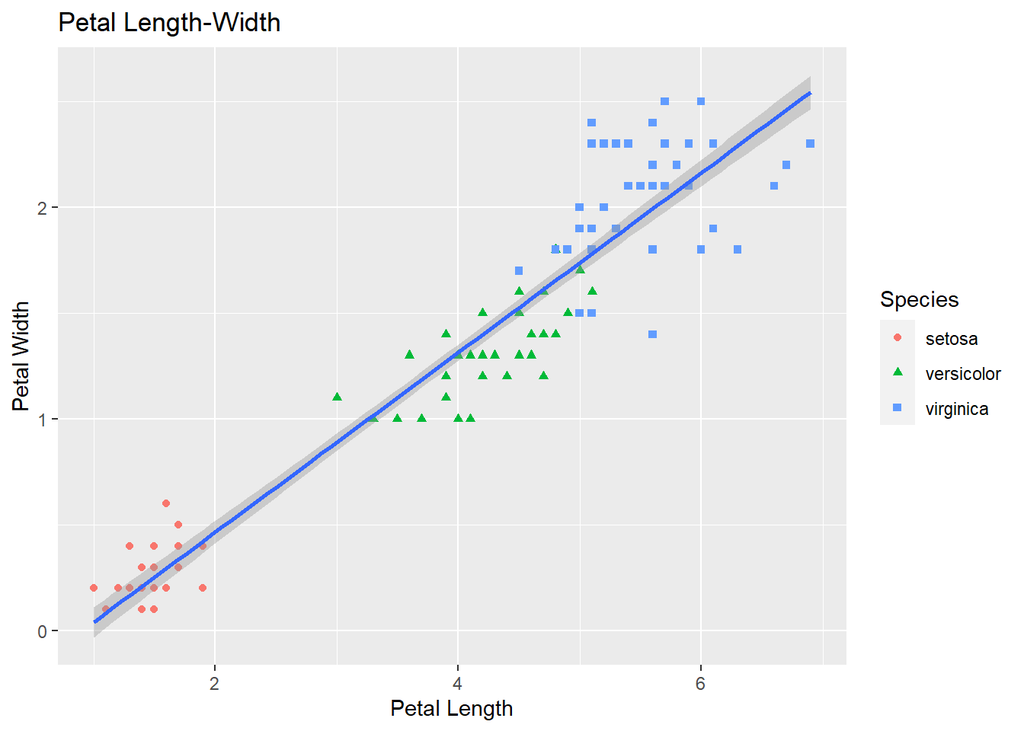

```r
#scatter plot: distribution of species based on Petal Length and Width
scatter <-base +
    geom_point(aes(color=Species, shape=Species)) +
    xlab("Petal Length") +
    ylab("Petal Width") +
    ggtitle("Petal Length-Width")+
    geom_smooth(method="lm")
print(scatter)
```

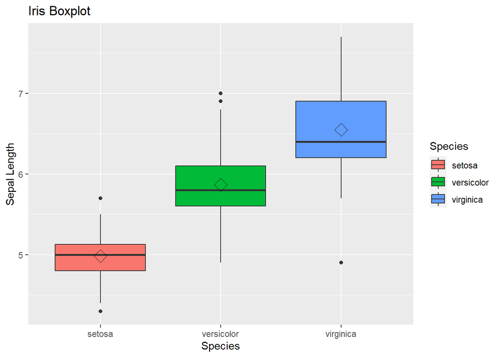

```r
#box plot: distribution of Species based on Sepal Length
box <- ggplot(data=trainset, aes(x=Species, y=Sepal.Length)) +
    geom_boxplot(aes(fill=Species)) +
    ylab("Sepal Length") +
    ggtitle("Iris Boxplot") +
    stat_summary(fun=mean, geom="point", shape=5, size=4)
print(box)
```

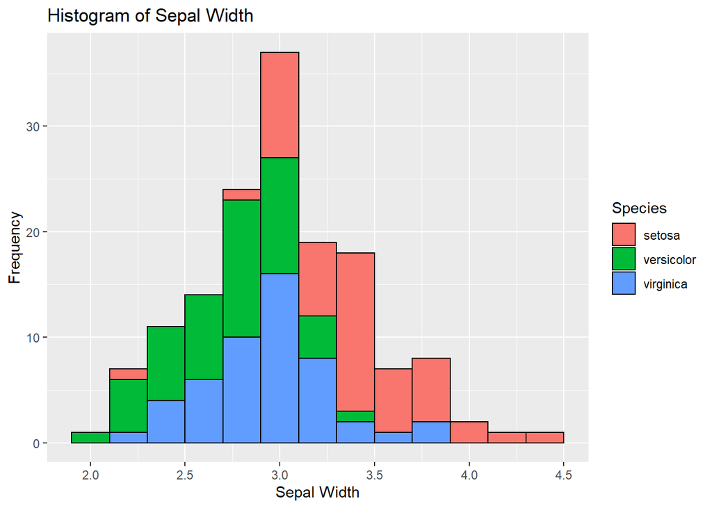

```r
#histogram: frequency of species of flower based on Sepal Width
histo <- ggplot(data=iris, aes(x=Sepal.Width)) +
    geom_histogram(binwidth=0.2, color="black", aes(fill=Species)) +
    xlab("Sepal Width") +
    ylab("Frequency") +
    ggtitle("Histogram of Sepal Width")
print(histo)
```

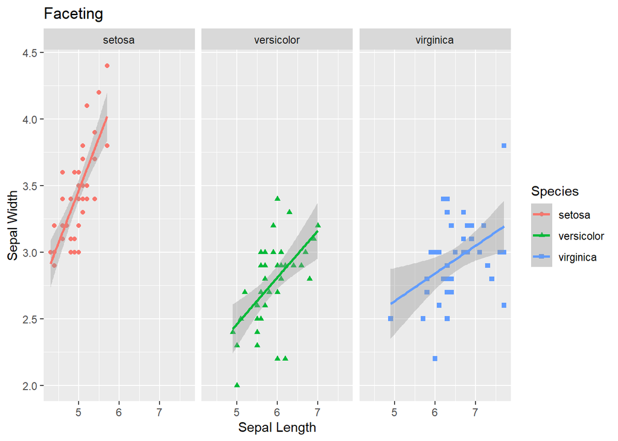

```r
#faceting: distribution of all species' Sepal Lengths and Widths
face <- ggplot(data=trainset, aes(Sepal.Length, y=Sepal.Width, color=Species))+
    geom_point(aes(shape=Species), size=1.5) +
    geom_smooth(method="lm") +
    xlab("Sepal Length") +
    ylab("Sepal Width") +
    ggtitle("Faceting") +
    facet_grid(. ~ Species)
print(face)
```

**-Machine Learning Models!-**

Finally, we’re ready to fit our dataset to some models! We’ll be building a few models and use the ‘trainset’ to try and narrow down which one is the best model for predicting the ‘testset,’ and then we’ll try to measure how it will preform in the real world.

*~Decision Tree Classifier~*

This kind of model classifies observations by sorting them down the ‘tree’ from the root node to the leaf node, which provides the classification for the observation. Each node specifies a test on a particular attribute and each branch from that node represents one of the possible values for that test.

```r
#fits model
model.rpart <- rpart(Species~.,data=trainset,method = 'class')

#prints model
print(model.rpart)
```

```
## n= 120
##
## node), split, n, loss, yval, (yprob)
##       * denotes terminal node
##
## 1) root 120 80 setosa (0.33333333 0.33333333 0.33333333)
##   2) Petal.Length< 2.45 40  0 setosa (1.00000000 0.00000000 0.00000000) *
##   3) Petal.Length>=2.45 80 40 versicolor (0.00000000 0.50000000 0.50000000)
##     6) Petal.Width< 1.75 43  4 versicolor (0.00000000 0.90697674 0.09302326) *
##     7) Petal.Width>=1.75 37  1 virginica (0.00000000 0.02702703 0.97297297) *
```

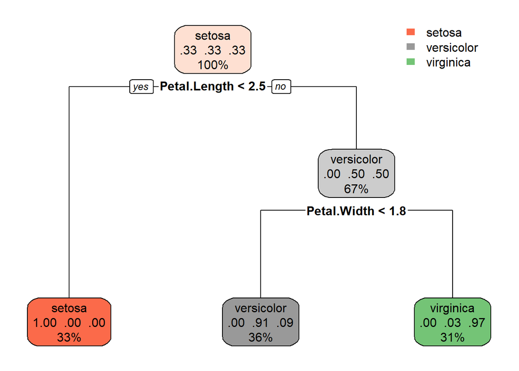

```r
#plots model
rpart.plot(model.rpart)
```

```r
#predictions on 'trainset'
treePred <- predict(model.rpart,newdata=testset[-5],type = 'class')
treePred
```

```
##          3         13         15         21         27         37         41
##     setosa     setosa     setosa     setosa     setosa     setosa     setosa
##         42         49         50         52         55         66         73
##     setosa     setosa     setosa versicolor versicolor versicolor versicolor
##         76         81         85         87         88         93        102
## versicolor versicolor versicolor versicolor versicolor versicolor  virginica
##        109        110        111        117        122        123        130
##  virginica  virginica  virginica  virginica  virginica  virginica versicolor
##        132        138
##  virginica  virginica
## Levels: setosa versicolor virginica
```

```r
#verifies accuracy on 'trainset'
confusionMatrix(predict(object = model.rpart,newdata = trainset[,1:4],type="class"),trainset$Species)
```

```
## Confusion Matrix and Statistics
##
##             Reference
## Prediction   setosa versicolor virginica
##   setosa         40          0         0
##   versicolor      0         39         4
##   virginica       0          1        36
##
## Overall Statistics
##
##                Accuracy : 0.9583
##                  95% CI : (0.9054, 0.9863)
##     No Information Rate : 0.3333
##     P-Value [Acc > NIR] : < 2.2e-16
##
##                   Kappa : 0.9375
##
##  Mcnemar's Test P-Value : NA
##
## Statistics by Class:
##
##                      Class: setosa Class: versicolor Class: virginica
## Sensitivity                 1.0000            0.9750           0.9000
## Specificity                 1.0000            0.9500           0.9875
## Pos Pred Value              1.0000            0.9070           0.9730
## Neg Pred Value              1.0000            0.9870           0.9518
## Prevalence                  0.3333            0.3333           0.3333
## Detection Rate              0.3333            0.3250           0.3000
## Detection Prevalence        0.3333            0.3583           0.3083
## Balanced Accuracy           1.0000            0.9625           0.9438
```

```r
#checks accuracy on 'testset'
pred_test<-predict(object = model.rpart,
                   newdata = testset[,1:4],
                   type="class")
confusionMatrix(pred_test,testset$Species)
```

```
## Confusion Matrix and Statistics
##
##             Reference
## Prediction   setosa versicolor virginica
##   setosa         10          0         0
##   versicolor      0         10         1
##   virginica       0          0         9
##
## Overall Statistics
##
##                Accuracy : 0.9667
##                  95% CI : (0.8278, 0.9992)
##     No Information Rate : 0.3333
##     P-Value [Acc > NIR] : 2.963e-13
##
##                   Kappa : 0.95
##
##  Mcnemar's Test P-Value : NA
##
## Statistics by Class:
##
##                      Class: setosa Class: versicolor Class: virginica
## Sensitivity                 1.0000            1.0000           0.9000
## Specificity                 1.0000            0.9500           1.0000
## Pos Pred Value              1.0000            0.9091           1.0000
## Neg Pred Value              1.0000            1.0000           0.9524
## Prevalence                  0.3333            0.3333           0.3333
## Detection Rate              0.3333            0.3333           0.3000
## Detection Prevalence        0.3333            0.3667           0.3000
## Balanced Accuracy           1.0000            0.9750           0.9500
```

*~Linear Discriminant Analysis~*